# Proportional Odds Logit Modeling for Pacific Oyster Color Preferences

Ernest O. Chuku

2023-07-31

## Data

> Read cleaned data and store as data frame - the data is in the S3 data structure.

```r
rm(list = ls()) #clear R environment
```

```r
df_Col <- read.csv("POLM_Premium_Shell_Colour_data.csv")
```

> View the data structure.

```r
str(df_Col)
```

```
## 'data.frame':    128 obs. of  4 variables:
##  $ Years  : int  25 25 25 25 30 30 30 30 12 12 ...
##  $ SCseg  : chr  "PROD" "PROD" "PROD" "PROD" ...
##  $ Col    : chr  "DARK" "LIGHT" "STRIP" "GOLD" ...
##  $ ColRANK: chr  "1st" "3rd" "2nd" "4th" ...
```

> Convert the outcome variable `ColRANK` and the other categorical variables `Col` and `SCseg` as factors.

```r
df_Col$ColRANK <- as.factor(df_Col$ColRANK)
df_Col$Col <- as.factor(df_Col$Col)
df_Col$SCseg <- as.factor(df_Col$SCseg)

str(df_Col)
```

```
## 'data.frame':    128 obs. of  4 variables:
##  $ Years  : int  25 25 25 25 30 30 30 30 12 12 ...
##  $ SCseg  : Factor w/ 3 levels "PROD","PRODTRAD",..: 1 1 1 1 2 2 2 2 3 3 ...
##  $ Col    : Factor w/ 4 levels "DARK","GOLD",..: 1 3 4 2 1 3 4 2 1 3 ...
##  $ ColRANK: Factor w/ 4 levels "1st","2nd","3rd",..: 1 3 2 4 1 2 4 3 2 4 ...
```

> Check the order of the outcome variable.

```r
levels(df_Col$ColRANK)
```

```
## [1] "1st" "2nd" "3rd" "4th"
```

> The outcome variable is ordinal. We, therefore, reorder the ranking levels from least to best. This is critical, and must be done!

```r
df_Col$ColRANK <- ordered(df_Col$ColRANK,
  levels = c("4th", "3rd", "2nd", "1st"))
levels(df_Col$ColRANK) # check the levels to confirm reordering
```

```
## [1] "4th" "3rd" "2nd" "1st"
```

```r
contrasts(df_Col$Col)
```

```
##       GOLD LIGHT STRIP
## DARK     0     0     0
## GOLD     1     0     0
## LIGHT    0     1     0
## STRIP    0     0     1
```

```r
contrasts(df_Col$SCseg)
```

```
##          PRODTRAD TRAD
## PROD            0    0
## PRODTRAD        1    0
## TRAD            0    1
```

> Once the data structure is checked we are ready to apply proportional odds logit models

## Fit the Proportional Odds Logistic Regression Models

> The `polr` function from the `MASS` package is used for proportional odds regression.

```r
library(MASS)
```

### POLR Model #1

```r
fit001 <- polr(ColRANK ~ Col,
              Hess = TRUE,
              data = df_Col,
              na.action = na.fail)
```

### POLR Model #2

```r
fit002 <- polr(ColRANK ~ Col + SCseg,
              Hess = TRUE,
              data = df_Col,
              na.action = na.fail)
```

### POLR Model #3

```r
fit003 <- polr(ColRANK ~ Col + SCseg + Col:SCseg,
              Hess = TRUE,
              data = df_Col,
              na.action = na.fail)
```

### Perform likelihood ratio tests of Models 1-3

```r
anova(fit001, fit002, fit003)
```

```
## Likelihood ratio tests of ordinal regression models
##
## Response: ColRANK
##                     Model Resid. df Resid. Dev   Test    Df    LR stat.
## 1                     Col       122   294.4187
## 2             Col + SCseg       120   294.3229 1 vs 2     2  0.09577717
## 3 Col + SCseg + Col:SCseg       114   260.7176 2 vs 3     6 33.60535080
##        Pr(Chi)
## 1
## 2 9.532400e-01
## 3 8.016771e-06
```

> Another model selection approach would be to specify the general model and conduct a stepwise backward and forward modelling. This is automated in R with the `step` function. Below, the `step` function also selects the model with interaction between `Col` and `SCseg` as the best model. We are double sure about the selected model.

```r
step(fit003, test = "Chisq", direction = "both") # perform a forward and backward stepwise model, and perform likelihood ratio test at each step
```

```
## Start:  AIC=288.72
## ColRANK ~ Col + SCseg + Col:SCseg
##
##             Df    AIC    LRT  Pr(>Chi)
## <none>         288.72
## - Col:SCseg  6 310.32 33.605 8.017e-06 ***
## ---
## Signif. codes:  0 '***' 0.001 '**' 0.01 '*' 0.05 '.' 0.1 ' ' 1
```

```
## Call:
## polr(formula = ColRANK ~ Col + SCseg + Col:SCseg, data = df_Col,
##     na.action = na.fail, Hess = TRUE)
##
## Coefficients:
##                ColGOLD               ColLIGHT               ColSTRIP
##             -4.3700981             -5.4067528             -2.7422675
##          SCsegPRODTRAD              SCsegTRAD  ColGOLD:SCsegPRODTRAD
##              0.7136507             -2.4988536             -0.4110935
## ColLIGHT:SCsegPRODTRAD ColSTRIP:SCsegPRODTRAD      ColGOLD:SCsegTRAD
##             -0.4011225             -1.2812285              0.7525272
##     ColLIGHT:SCsegTRAD     ColSTRIP:SCsegTRAD
##              4.8310589              4.0415405
##
## Intercepts:
##   4th|3rd   3rd|2nd   2nd|1st
## -5.061940 -3.226954 -1.254295
##
## Residual Deviance: 260.7176
## AIC: 288.7176
```

```r
summary(fit003)
```

```
## Call:
## polr(formula = ColRANK ~ Col + SCseg + Col:SCseg, data = df_Col,
##     na.action = na.fail, Hess = TRUE)
##
## Coefficients:
##                          Value Std. Error t value
## ColGOLD                -4.3701     0.9252 -4.7234
## ColLIGHT               -5.4068     0.9214 -5.8677
## ColSTRIP               -2.7423     0.8272 -3.3152
## SCsegPRODTRAD           0.7137     1.2498  0.5710
## SCsegTRAD              -2.4989     0.8878 -2.8148
## ColGOLD:SCsegPRODTRAD  -0.4111     1.5160 -0.2712
## ColLIGHT:SCsegPRODTRAD -0.4011     1.5100 -0.2656
## ColSTRIP:SCsegPRODTRAD -1.2812     1.4845 -0.8631
## ColGOLD:SCsegTRAD       0.7525     1.2397  0.6070
## ColLIGHT:SCsegTRAD      4.8311     1.2141  3.9792
## ColSTRIP:SCsegTRAD      4.0415     1.2009  3.3655
##
## Intercepts:
##         Value   Std. Error t value
## 4th|3rd -5.0619  0.7765    -6.5193
## 3rd|2nd -3.2270  0.7216    -4.4722
## 2nd|1st -1.2543  0.6518    -1.9244
##
## Residual Deviance: 260.7176
## AIC: 288.7176
```

> It is easier to interpret the model with p-values instead of the t-values. Calculate the p-values and append to the coefficients table

```r
# get coefficients (it's in matrix form)
coefficients <- summary(fit003)$coefficients
# calculate p-values
p_value <- (1 - pnorm(abs(coefficients[ ,"t value"]), 0, 1))*2
# bind back to coefficients
(coefficients <- cbind(coefficients, p_value))
```

```
##                             Value Std. Error    t value      p_value
## ColGOLD                -4.3700981  0.9252023 -4.7233974 2.319370e-06
## ColLIGHT               -5.4067528  0.9214459 -5.8676834 4.419261e-09
## ColSTRIP               -2.7422675  0.8271758 -3.3152173 9.157192e-04
## SCsegPRODTRAD           0.7136507  1.2497696  0.5710259 5.679821e-01
## SCsegTRAD              -2.4988536  0.8877701 -2.8147529 4.881475e-03
## ColGOLD:SCsegPRODTRAD  -0.4110935  1.5160276 -0.2711649 7.862642e-01
## ColLIGHT:SCsegPRODTRAD -0.4011225  1.5099828 -0.2656470 7.905110e-01
## ColSTRIP:SCsegPRODTRAD -1.2812285  1.4845094 -0.8630653 3.881016e-01
## ColGOLD:SCsegTRAD       0.7525272  1.2396749  0.6070359 5.438271e-01
## ColLIGHT:SCsegTRAD      4.8310589  1.2140678  3.9792333 6.913788e-05
## ColSTRIP:SCsegTRAD      4.0415405  1.2008838  3.3654717 7.641292e-04
## 4th|3rd                -5.0619398  0.7764596 -6.5192572 7.065637e-11
## 3rd|2nd                -3.2269542  0.7215658 -4.4721551 7.743523e-06
## 2nd|1st                -1.2542951  0.6517955 -1.9243691 5.430833e-02
```

> Odds ratios are very useful for explaining the parameter estimates. We calculate the odds ratios and further calculate a less biased version recommended for categorical predictors (Baker, 2006).

```r
# calculate odds ratios
odds_ratio <- exp(coefficients[ ,"Value"]) #this is biased for categorical/dummy variables and tends to slightly overstate the effect
# for reduced bias odds ratios for dummy variables, use
odds_ratio_cat <- exp((coefficients[ ,"Value"])-((((coefficients[ ,"Std. Error"])^2)*(coefficients[ ,"Value"]))/2))
# combine with coefficient and p_value
(coefficients <- cbind(
  coefficients[ ,c("Value", "Std. Error", "p_value")],
  odds_ratio, odds_ratio_cat
))
```

```
##                             Value Std. Error      p_value   odds_ratio
## ColGOLD                -4.3700981  0.9252023 2.319370e-06 1.265000e-02
## ColLIGHT               -5.4067528  0.9214459 4.419261e-09 4.486184e-03
## ColSTRIP               -2.7422675  0.8271758 9.157192e-04 6.442410e-02
## SCsegPRODTRAD           0.7136507  1.2497696 5.679821e-01 2.041430e+00
## SCsegTRAD              -2.4988536  0.8877701 4.881475e-03 8.217916e-02
## ColGOLD:SCsegPRODTRAD  -0.4110935  1.5160276 7.862642e-01 6.629249e-01
## ColLIGHT:SCsegPRODTRAD -0.4011225  1.5099828 7.905110e-01 6.695681e-01
## ColSTRIP:SCsegPRODTRAD -1.2812285  1.4845094 3.881016e-01 2.776960e-01
## ColGOLD:SCsegTRAD       0.7525272  1.2396749 5.438271e-01 2.122357e+00
## ColLIGHT:SCsegTRAD      4.8310589  1.2140678 6.913788e-05 1.253436e+02
## ColSTRIP:SCsegTRAD      4.0415405  1.2008838 7.641292e-04 5.691395e+01
## 4th|3rd                -5.0619398  0.7764596 7.065637e-11 6.333262e-03
## 3rd|2nd                -3.2269542  0.7215658 7.743523e-06 3.967817e-02
## 2nd|1st                -1.2542951  0.6517955 5.430833e-02 2.852769e-01
##                        odds_ratio_cat
## ColGOLD                    0.08210982
## ColLIGHT                   0.04453779
## ColSTRIP                   0.16462080
## SCsegPRODTRAD              1.16919637
## SCsegTRAD                  0.21999827
## ColGOLD:SCsegPRODTRAD      1.06324203
## ColLIGHT:SCsegPRODTRAD     1.05777406
## ColSTRIP:SCsegPRODTRAD     1.13943977
## ColGOLD:SCsegTRAD          1.19039788
## ColLIGHT:SCsegTRAD         3.56321667
## ColSTRIP:SCsegTRAD         3.08744330
## 4th|3rd                    0.02912831
## 3rd|2nd                    0.09191549
## 2nd|1st                    0.37237294
```

### Estimate model fit parameters

```r
nobs(fit003) #observations
```

```
## [1] 128
```

```r
logLik(fit003) #log likelihood
```

```
## 'log Lik.' -130.3588 (df=14)
```

```r
DescTools::PseudoR2(fit003, which = "McFadden")
```

```
##  McFadden
## 0.2653595
```

```r
DescTools::PseudoR2(fit003, which = "Nagelkerke")
```

```
## Nagelkerke
##  0.5555688
```

### Perform type III test for the model

```r
library(car)
Anova(fit003, type = 3, test.statistic = "Wald")
```

```
## Analysis of Deviance Table (Type III tests)
##
## Response: ColRANK
##           LR Chisq Df Pr(>Chisq)
## Col         47.079  3  3.343e-10 ***
## SCseg       12.584  2   0.001851 **
## Col:SCseg   33.605  6  8.017e-06 ***
## ---
## Signif. codes:  0 '***' 0.001 '**' 0.01 '*' 0.05 '.' 0.1 ' ' 1
```

### View the effects

> For POLM, this is a plot of the cumulative probabilities with standard errors. NB: `latent = FALSE` computes effects of POLM as individual-level probabilities and logits. `latent = TRUE` will compute effects of POLM on the scale of the latent response.

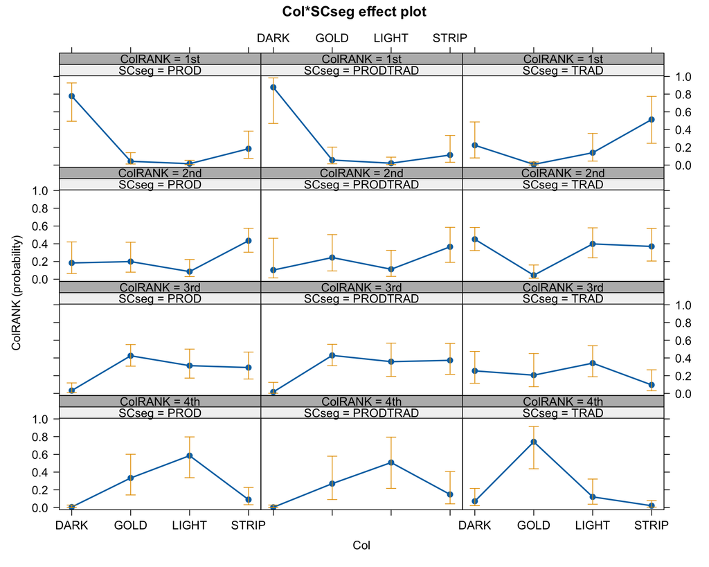

```r
library(effects)
plot(allEffects(fit003))
```

## Dealing with Interaction Term

> The estimates for the interaction term in the model summary are tricky!! Needs a bit of extra work to explain them. To make life easier, because there is enough evidence of a significant “SCseg” and “Col” interactions (at the 10% level), “SCseg” and “Col” are bound to form a single categorical variable “SCseg|Col” with 12 levels. One combination is selected as the reference level.

> We concatenate the variables in the interaction term and refit the model. We go through all the procedures to include p-values, odds ratios, model fit parameters, etc.

### Model #4 (with concateated iteraction term)

```r
#concatenate string/factor variables and store as a new column
df_Col$SCsegCol <- as.factor(paste(df_Col$SCseg, df_Col$Col, sep = "|")) #combining SCseg and Col
# fit new model
fit004 <- polr(ColRANK ~ SCsegCol,
              Hess = TRUE,
              data = df_Col,
              na.action = na.fail)

# get coefficients (it's in matrix form)
coefficients <- summary(fit004)$coefficients
# calculate p-values
p_value <- (1 - pnorm(abs(coefficients[ ,"t value"]), 0, 1))*2
# bind back to coefficients
coefficients <- cbind(coefficients, p_value)
# calculate odds ratios
odds_ratio <- exp(coefficients[ ,"Value"]) #this is biased for categorical/dummy variables and tends to slightly overstate the effect
# for reduced bias odds ratios for dummy variables, use
odds_ratio_cat <- exp((coefficients[ ,"Value"])-((((coefficients[ ,"Std. Error"])^2)*(coefficients[ ,"Value"]))/2))
# combine with coefficient and p_value
(coefficients <- cbind(
  coefficients[ ,c("Value", "Std. Error", "p_value")],
  odds_ratio, odds_ratio_cat
))
```

```
##                             Value Std. Error      p_value  odds_ratio
## SCsegColPROD|GOLD      -4.3698194  0.9252347 2.324699e-06 0.012653525
## SCsegColPROD|LIGHT     -5.4071734  0.9214955 4.415523e-09 0.004484298
## SCsegColPROD|STRIP     -2.7425627  0.8272237 9.151795e-04 0.064405086
## SCsegColPRODTRAD|DARK   0.7118816  1.2493150 5.688015e-01 2.037821958
## SCsegColPRODTRAD|GOLD  -4.0680507  0.9783633 3.210229e-05 0.017110710
## SCsegColPRODTRAD|LIGHT -5.0951722  1.0076075 4.265664e-07 0.006126251
## SCsegColPRODTRAD|STRIP -3.3103515  0.9509562 4.994025e-04 0.036503339
## SCsegColTRAD|DARK      -2.4997394  0.8878187 4.868674e-03 0.082106391
## SCsegColTRAD|GOLD      -6.1164596  1.0171999 1.820803e-09 0.002206253
## SCsegColTRAD|LIGHT     -3.0744183  0.9023819 6.568027e-04 0.046216506
## SCsegColTRAD|STRIP     -1.1995838  0.8853863 1.754588e-01 0.301319609
## 4th|3rd                -5.0620836  0.7765063 7.075407e-11 0.006332352
## 3rd|2nd                -3.2272434  0.7216233 7.741911e-06 0.039666695
## 2nd|1st                -1.2546505  0.6518609 5.426425e-02 0.285175512
##                        odds_ratio_cat
## SCsegColPROD|GOLD          0.08213366
## SCsegColPROD|LIGHT         0.04453803
## SCsegColPROD|STRIP         0.16460673
## SCsegColPRODTRAD|DARK      1.16921608
## SCsegColPRODTRAD|GOLD      0.11990059
## SCsegColPRODTRAD|LIGHT     0.08137583
## SCsegColPRODTRAD|STRIP     0.16307473
## SCsegColTRAD|DARK          0.21990392
## SCsegColTRAD|GOLD          0.05222872
## SCsegColTRAD|LIGHT         0.16159218
## SCsegColTRAD|STRIP         0.48219747
## 4th|3rd                    0.02913074
## 3rd|2nd                    0.09190813
## 2nd|1st                    0.37228865
```

```r
nobs(fit004)
```

```
## [1] 128
```

```r
logLik(fit004)
```

```
## 'log Lik.' -130.3588 (df=14)
```

```r
DescTools::PseudoR2(fit004, which = "McFadden")
```

```
##  McFadden
## 0.2653595
```

```r
DescTools::PseudoR2(fit004, which = "Nagelkerke")
```

```
## Nagelkerke
##  0.5555688
```

```r
Anova(fit004, type = 3, test.statistic = "Wald")
```

```
## Analysis of Deviance Table (Type III tests)
##
## Response: ColRANK
##          LR Chisq Df Pr(>Chisq)
## SCsegCol   94.174 11  2.525e-15 ***
## ---
## Signif. codes:  0 '***' 0.001 '**' 0.01 '*' 0.05 '.' 0.1 ' ' 1
```

> Now the estimates are much easier to comprehend. You can observe that Models #3 and #4 are the same!

> Let’s view the effects plot for Model #4. For POLR, this a plot of the cumulative probabilities with standard errors. NB: `latent = FALSE` computes effects of POLR model as individual-level probabilities and logits. `latent = TRUE` will compute effects of POLR model on the scale of the latent response.

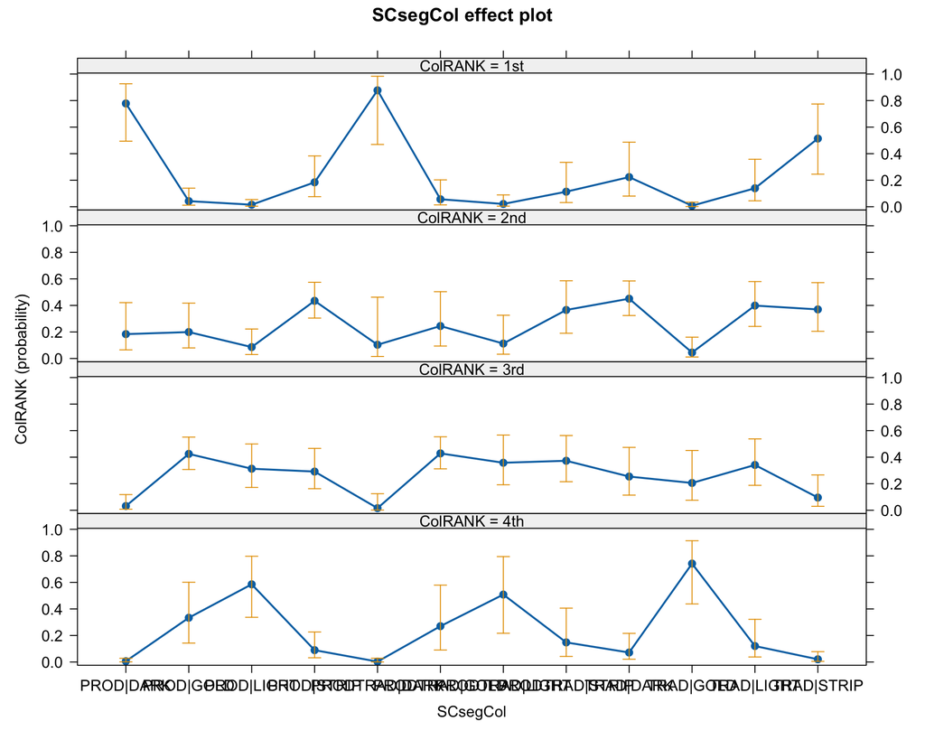

```r
plot(allEffects((fit004), latent = FALSE))
```

> The probability estimates (effects) among the ranks is still the same as for Model #3.

Multiple comparisons of model coefficients

```r
library(emmeans)
#get estimated means coefficients of factor levels for a categorical predictor and store
em <- emmeans(fit004, "SCsegCol")
#get multiple comparisons OR contrasts among the factor levels
#contrast(em, "pairwise", adjust = "Tukey")
#save multiple comparisons as a dataframe
df_EstCOMP <- data.frame(contrast(em, "pairwise", adjust = "Tukey"), check.names = FALSE, stringsAsFactors = FALSE)
# calculate odds ratios
df_EstCOMP$OR <- round((exp(df_EstCOMP[ ,"estimate"])-1)*100)
# for reduced bias odds ratios for the differences in parameter estimates, use
df_EstCOMP$OR_cat <- round(((exp((df_EstCOMP[ ,"estimate"])-((((df_EstCOMP[ ,"SE"])^2)*(df_EstCOMP[ ,"estimate"]))/2)))-1)*100)
#reorder such that contrasts significant p-values will be on top
df_EstCOMP_ord <- df_EstCOMP[order(df_EstCOMP$p.value),]
# View the reordered contrasts
head(df_EstCOMP_ord)
```

```
##                      contrast  estimate        SE  df   z.ratio      p.value
## 9       PROD|DARK - TRAD|GOLD  6.116460 1.0171999 Inf  6.013036 1.197272e-07
## 2      PROD|DARK - PROD|LIGHT  5.407173 0.9214955 Inf  5.867824 2.899608e-07
## 43  PRODTRAD|DARK - TRAD|GOLD  6.828341 1.3232400 Inf  5.160319 1.594993e-05
## 65     TRAD|GOLD - TRAD|STRIP -4.916876 0.9685285 Inf -5.076645 2.477340e-05
## 6  PROD|DARK - PRODTRAD|LIGHT  5.095172 1.0076075 Inf  5.056703 2.748511e-05
## 23 PROD|LIGHT - PRODTRAD|DARK -6.119055 1.2511779 Inf -4.890635 6.423649e-05
##       OR OR_cat
## 9  45226   1815
## 2  22200   2145
## 43 92266    134
## 65   -99    -93
## 6  16223   1129
## 23  -100    -74
```

Select specific contrasts of model coefficients from `df_EstCOMP_ord` for comparison

```r
df_EstCOMP_ord[is.element(df_EstCOMP_ord$contrast,
                          c('PRODTRAD|DARK - TRAD|STRIP',
                            'PRODTRAD|DARK - TRAD|DARK',
                            'PROD|STRIP - PRODTRAD|DARK')),]
```

```
##                      contrast  estimate       SE  df   z.ratio   p.value   OR
## 31 PROD|STRIP - PRODTRAD|DARK -3.454444 1.182816 Inf -2.920525 0.1335126  -97
## 42  PRODTRAD|DARK - TRAD|DARK  3.211621 1.225793 Inf  2.620036 0.2681494 2382
## 45 PRODTRAD|DARK - TRAD|STRIP  1.911465 1.223161 Inf  1.562726 0.9223736  576
##    OR_cat
## 31    -65
## 42    122
## 45     62
```

Calculating specific, odds ratios and odds for the contrasts NORMAL (run the code as is)

```r
library(dplyr)

#Subset data
df_EstCOMP_select <- df_EstCOMP %>% filter(contrast == "PRODTRAD|DARK - TRAD|STRIP")
# for reduced bias odds ratios for the differences in parameter estimates, use
ORcat <- exp((df_EstCOMP_select$estimate)-((((df_EstCOMP_select$SE)^2)*(df_EstCOMP_select$estimate))/2))

#ORcat <- exp((df_EstCOMP_select$estimate)-(((df_EstCOMP_select$SE)^2)/2))
Odds_cat <- (ORcat-1)*100
ORnorm <- exp(df_EstCOMP_select$estimate)
Odds_norm <- (ORnorm-1)*100

ORcat #bias-reduced odds ratio; not appropriate for small odds ratios
```

```
## [1] 1.618616
```

```r
Odds_cat #bias-reduced odds;
```

```
## [1] 61.86164
```

```r
ORnorm #normal odds ratio; biased for categorical variables
```

```
## [1] 6.762992
```

```r
Odds_norm #normal odds
```

```
## [1] 576.2992
```

Calculating specific odds for reverse differences that do not show above; REVERSE negative to positive (use absolute `abs` to convert negative estimate to positive)

```r
#Subset data
df_EstCOMP_select <- df_EstCOMP %>% filter(contrast == "PROD|STRIP - PRODTRAD|DARK") #reversing to "PROD|DARK - PRODTRAD|STRIP"
# for reduced bias odds ratios for the differences in parameter estimates, use
ORcat <- exp((abs(df_EstCOMP_select$estimate))-((((df_EstCOMP_select$SE)^2)*(abs(df_EstCOMP_select$estimate)))/2))
# the bias-reduced odds; not appropriate for small odds ratios
Odds_cat <- (ORcat-1)*100

#for normal odds ratio
ORnorm <- exp((abs(df_EstCOMP_select$estimate)))
#Normal odds
Odds_norm <- (ORnorm-1)*100

#view the results
ORcat
```

```
## [1] 2.823469
```

```r
Odds_cat
```

```
## [1] 182.3469
```

```r
ORnorm
```

```
## [1] 31.6407
```

```r
Odds_norm
```

```
## [1] 3064.07
```

Calculating specific odds for reverse differences that do not show above REVERSE positive to negative (multiply the estimate by `-1` to negate it)

```r
#Subset data
df_EstCOMP_select <- df_EstCOMP %>% filter(contrast == "PRODTRAD|DARK - TRAD|STRIP") #reversing to "PRODTRAD|STRIP - TRAD|DARK"
#Reverse estimate positive to negative
REVestimate <- (-1)*(df_EstCOMP_select$estimate)
# for reduced bias odds ratios for the differences in parameter estimates, use
ORcat <- exp(REVestimate-((((df_EstCOMP_select$SE)^2)*(REVestimate))/2))

Odds_cat <- (ORcat-1)*100
ORnorm <- exp(REVestimate)
Odds_norm <- (ORnorm-1)*100

#view the results
ORcat
```

```
## [1] 0.6178116
```

```r
Odds_cat
```

```
## [1] -38.21884
```

```r
ORnorm
```

```
## [1] 0.1478636
```

```r
Odds_norm
```

```
## [1] -85.21364
```

## Estimating predicted probabilities

```r
model_best <- fit003
```

> How does the data frame look like at this point?

```r
head(df_Col)
```

```
##   Years    SCseg   Col ColRANK       SCsegCol
## 1    25     PROD  DARK     1st      PROD|DARK
## 2    25     PROD LIGHT     3rd     PROD|LIGHT
## 3    25     PROD STRIP     2nd     PROD|STRIP
## 4    25     PROD  GOLD     4th      PROD|GOLD
## 5    30 PRODTRAD  DARK     1st  PRODTRAD|DARK
## 6    30 PRODTRAD LIGHT     2nd PRODTRAD|LIGHT
```

> Let’s select on the columns for the predictions, i.e., the variables used in the model.

```r
# only keep what is used in the analysis
df_ColRANKselect <- dplyr::select(df_Col, Col, SCseg, ColRANK)
levels(df_ColRANKselect$ColRANK) # check the levels of ColRANK again
```

```
## [1] "4th" "3rd" "2nd" "1st"
```

```r
head(df_ColRANKselect)
```

```
##     Col    SCseg ColRANK
## 1  DARK     PROD     1st
## 2 LIGHT     PROD     3rd
## 3 STRIP     PROD     2nd
## 4  GOLD     PROD     4th
## 5  DARK PRODTRAD     1st
## 6 LIGHT PRODTRAD     2nd
```

```r
# add the predicted probabilities to the data frame
df_ColRANKselect <- cbind(df_ColRANKselect, predict(model_best, type = "probs"))

head(df_ColRANKselect) # show the probabilities
```

```
##     Col    SCseg ColRANK         4th        3rd        2nd        1st
## 1  DARK     PROD     1st 0.006293404 0.03187049 0.18379363 0.77804248
## 2 LIGHT     PROD     3rd 0.585359174 0.31306152 0.08609706 0.01548225
## 3 STRIP     PROD     2nd 0.089506760 0.29163928 0.43462770 0.18422625
## 4  GOLD     PROD     4th 0.333623495 0.42463290 0.19928352 0.04246008
## 5  DARK PRODTRAD     1st 0.003092770 0.01597311 0.10354381 0.87739031
## 6 LIGHT PRODTRAD     2nd 0.508070470 0.35807164 0.11281508 0.02104280
```

> We tidy up the predicted probabilities for plotting.

```r
library(tidyverse)
# convert the data frame to long format for plotting
df_plot <- gather(df_ColRANKselect, key = Predicted, value = Probability, 4:7) #edit column numbers to suit your data frame

head(df_plot) # examine the data
```

```
##     Col    SCseg ColRANK Predicted Probability
## 1  DARK     PROD     1st       4th 0.006293404
## 2 LIGHT     PROD     3rd       4th 0.585359174
## 3 STRIP     PROD     2nd       4th 0.089506760
## 4  GOLD     PROD     4th       4th 0.333623495
## 5  DARK PRODTRAD     1st       4th 0.003092770
## 6 LIGHT PRODTRAD     2nd       4th 0.508070470
```

> Remove duplicate rows - rows with repeated probabilities

```r
# only keep the columns we need and remove duplicate rows
df_plot <- df_plot %>% dplyr::select(Col, SCseg, Predicted, Probability) %>%
  unique()
# ensure Predicted column is ordered
df_plot$Predicted <- ordered(df_plot$Predicted,
  levels = c("4th", "3rd", "2nd", "1st"))
# rearrange the rows
df_plot <- df_plot %>%  arrange(Col, SCseg, Predicted)

df_plot # look at the whole data frame
```

```
##      Col    SCseg Predicted Probability
## 1   DARK     PROD       4th 0.006293404
## 2   DARK     PROD       3rd 0.031870489
## 3   DARK     PROD       2nd 0.183793628
## 4   DARK     PROD       1st 0.778042479
## 5   DARK PRODTRAD       4th 0.003092770
## 6   DARK PRODTRAD       3rd 0.015973110
## 7   DARK PRODTRAD       2nd 0.103543814
## 8   DARK PRODTRAD       1st 0.877390306
## 9   DARK     TRAD       4th 0.071552244
## 10  DARK     TRAD       3rd 0.254059429
## 11  DARK     TRAD       2nd 0.450744816
## 12  DARK     TRAD       1st 0.223643511
## 13  GOLD     PROD       4th 0.333623495
## 14  GOLD     PROD       3rd 0.424632899
```

[output cut: 34 more lines]

## Plot stack column chart of predicted probabilities for the model

```r
library(ggplot2)
library(ggthemes)     # provides additional ggplot themes
library(RColorBrewer) # provides additional colors
library(cowplot)      # place multiple ggplots side by side
```

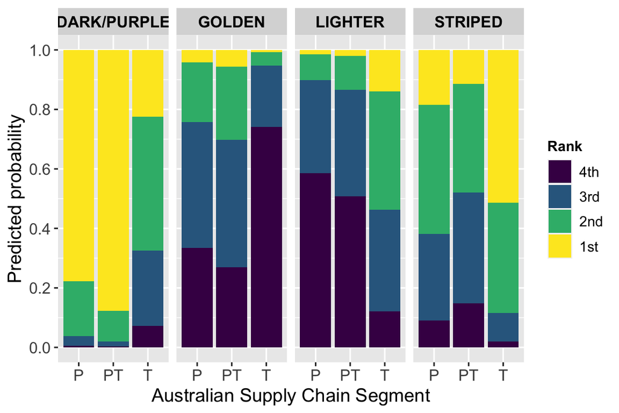

```r
df_plot2 <- df_plot
levels(df_plot2$Col)[levels(df_plot2$Col)=="DARK"] <- "DARK/PURPLE"
levels(df_plot2$Col)[levels(df_plot2$Col)=="GOLD"] <- "GOLDEN"
levels(df_plot2$Col)[levels(df_plot2$Col)=="LIGHT"] <- "LIGHTER"
levels(df_plot2$Col)[levels(df_plot2$Col)=="STRIP"] <- "STRIPED"

plot_ColRANK <- ggplot(df_plot2, aes(x = SCseg, y = Probability, fill = Predicted)) +
  geom_col(position = position_stack(reverse = TRUE)) +
  scale_y_continuous(breaks = c(0.0,0.2,0.4,0.6,0.8,1.0)) +
  facet_wrap(~ Col, ncol=6) +
  labs(x = "Australian Supply Chain Segment", y = "Predicted probability", fill = "Rank") +
  scale_x_discrete(labels=c("PROD" = "P", "PRODTRAD" = "PT", "TRAD" = "T")) +
theme(legend.title = element_text(size=10, face="bold")) +
  theme(legend.text = element_text(size=10))

plot_ColRANKfin <- plot_ColRANK +
  theme(axis.title.x = element_text(size=13)) +
  theme(axis.title.y = element_text(size=13)) +
  theme(axis.text.x = element_text(size=11)) +
  theme(axis.text.y = element_text(size=11)) +
  theme(strip.text.x = element_text(size = 11, color = "black", face = "bold"))

plot_ColRANKfin
```

## Predict mean categorical rank outcomes for specific traits of in each state

```r
# Get levels of each categorical predictor using the terms in the model
LEVELS1 <- levels(df_ColRANKselect$Col)
LEVELS2 <- levels(df_ColRANKselect$SCseg)
```

```r
# Create a data.frame to store the predictions
df_predRANKS <- data.frame(
  Col   = rep(LEVELS1, length(LEVELS2)),
  SCseg = rep(LEVELS2, each=length(LEVELS1))
)
```

```r
# Add the predictions
df_predRANKS$predRANKS <- predict(model_best, df_predRANKS)

# View the predicted ranks
df_predRANKS
```

```
##      Col    SCseg predRANKS
## 1   DARK     PROD       1st
## 2   GOLD     PROD       3rd
## 3  LIGHT     PROD       4th
## 4  STRIP     PROD       2nd
## 5   DARK PRODTRAD       1st
## 6   GOLD PRODTRAD       3rd
## 7  LIGHT PRODTRAD       4th
## 8  STRIP PRODTRAD       3rd
## 9   DARK     TRAD       2nd
## 10  GOLD     TRAD       4th
## 11 LIGHT     TRAD       2nd
## 12 STRIP     TRAD       1st
```

```r
#sort by SCseg and predRANKS in descending order
df_predRANKS$predRANKS <- ordered(df_predRANKS$predRANKS)
df_predRANKS_ord <- df_predRANKS[order(df_predRANKS$SCseg, df_predRANKS$predRANKS, decreasing = TRUE),]
# View the ordered predicted ranks
df_predRANKS_ord
```

```
##      Col    SCseg predRANKS
## 12 STRIP     TRAD       1st
## 9   DARK     TRAD       2nd
## 11 LIGHT     TRAD       2nd
## 10  GOLD     TRAD       4th
## 5   DARK PRODTRAD       1st
## 6   GOLD PRODTRAD       3rd
## 8  STRIP PRODTRAD       3rd
## 7  LIGHT PRODTRAD       4th
## 1   DARK     PROD       1st
## 4  STRIP     PROD       2nd
## 2   GOLD     PROD       3rd
## 3  LIGHT     PROD       4th
```

## Testing the Proportionality Assumption

### Brant-Wald Test

```r
brant::brant(fit001)
```

```
## --------------------------------------------
## Test for X2  df  probability
## --------------------------------------------
## Omnibus      19.01   6   0
## ColGOLD      4.75    2   0.09
## ColLIGHT 0.03    2   0.99
## ColSTRIP 2.61    2   0.27
## --------------------------------------------
##
## H0: Parallel Regression Assumption holds
```

```r
brant::brant(fit002)
```

```
## --------------------------------------------
## Test for X2  df  probability
## --------------------------------------------
## Omnibus      19.01   10  0.04
## ColGOLD      4.75    2   0.09
## ColLIGHT 0.03    2   0.99
## ColSTRIP 2.61    2   0.27
## SCsegPRODTRAD    0   2   1
## SCsegTRAD    0   2   1
## --------------------------------------------
##
## H0: Parallel Regression Assumption holds
```

### Graphical Method [Manually Checking the proportional odds assumption (see detailed explanations at https://stats.oarc.ucla.edu/r/dae/ordinal-logistic-regression/)]

```r
library(Hmisc)

sf <- function(y) {
  c('Y>=1' = qlogis(mean(y >= 1)),
    'Y>=2' = qlogis(mean(y >= 2)),
    'Y>=3' = qlogis(mean(y >= 3)),
    'Y>=4' = qlogis(mean(y >= 4)))
}

(s <- with(df_Col, summary(as.numeric(ColRANK) ~ Col + SCseg + Col:SCseg, fun=sf)))
```

```
## as.numeric(ColRANK)      N= 128
##
## +-------+--------+---+----+---------+---------+----------+
## |       |        |  N|Y>=1|     Y>=2|     Y>=3|      Y>=4|
## +-------+--------+---+----+---------+---------+----------+
## |    Col|    DARK| 32| Inf|3.4339872| 1.945910| 0.5108256|
## |       |    GOLD| 32| Inf|0.1251631|-1.686399|-1.9459101|
## |       |   LIGHT| 32| Inf|0.3794896|-1.272966|-2.7080502|
## |       |   STRIP| 32| Inf|2.2686835| 1.098612|-1.4663371|
## +-------+--------+---+----+---------+---------+----------+
## |  SCseg|    PROD| 52| Inf|1.0986123| 0.000000|-1.0986123|
## |       |PRODTRAD| 32| Inf|1.0986123| 0.000000|-1.0986123|
## |       |    TRAD| 44| Inf|1.0986123| 0.000000|-1.0986123|
## +-------+--------+---+----+---------+---------+----------+
## |Overall|        |128| Inf|1.0986123| 0.000000|-1.0986123|
## +-------+--------+---+----+---------+---------+----------+
```

```r
levels(df_Col$ColRANK)
```

```
## [1] "4th" "3rd" "2nd" "1st"
```

```r
levels(df_Col$SCseg)
```

```
## [1] "PROD"     "PRODTRAD" "TRAD"
```

```r
summary(glm(I(as.numeric(ColRANK) >= 2) ~ Col, family="binomial", data = df_Col))
```

```
##
## Call:
## glm(formula = I(as.numeric(ColRANK) >= 2) ~ Col, family = "binomial",
##     data = df_Col)
##
## Coefficients:
##             Estimate Std. Error z value Pr(>|z|)
## (Intercept)    3.434      1.016   3.380 0.000725 ***
## ColGOLD       -3.309      1.076  -3.075 0.002104 **
## ColLIGHT      -3.054      1.078  -2.834 0.004600 **
## ColSTRIP      -1.165      1.183  -0.985 0.324705
## ---
## Signif. codes:  0 '***' 0.001 '**' 0.01 '*' 0.05 '.' 0.1 ' ' 1
##
## (Dispersion parameter for binomial family taken to be 1)
##
##     Null deviance: 143.96  on 127  degrees of freedom
## Residual deviance: 116.28  on 124  degrees of freedom
## AIC: 124.28
##
## Number of Fisher Scoring iterations: 6
```

```r
summary(glm(I(as.numeric(ColRANK) >= 3) ~ Col, family="binomial", data = df_Col))
```

```
##
## Call:
## glm(formula = I(as.numeric(ColRANK) >= 3) ~ Col, family = "binomial",
##     data = df_Col)
##
## Coefficients:
##             Estimate Std. Error z value Pr(>|z|)
## (Intercept)   1.9459     0.5345   3.640 0.000272 ***
## ColGOLD      -3.6323     0.7230  -5.024 5.06e-07 ***
## ColLIGHT     -3.2189     0.6845  -4.702 2.57e-06 ***
## ColSTRIP     -0.8473     0.6726  -1.260 0.207759
## ---
## Signif. codes:  0 '***' 0.001 '**' 0.01 '*' 0.05 '.' 0.1 ' ' 1
##
## (Dispersion parameter for binomial family taken to be 1)
##
##     Null deviance: 177.45  on 127  degrees of freedom
## Residual deviance: 121.46  on 124  degrees of freedom
## AIC: 129.46
##
## Number of Fisher Scoring iterations: 4
```

```r
summary(glm(I(as.numeric(ColRANK) >= 4) ~ Col, family="binomial", data = df_Col))
```

```
##
## Call:
## glm(formula = I(as.numeric(ColRANK) >= 4) ~ Col, family = "binomial",
##     data = df_Col)
##
## Coefficients:
##             Estimate Std. Error z value Pr(>|z|)
## (Intercept)   0.5108     0.3651   1.399 0.161827
## ColGOLD      -2.4567     0.6473  -3.795 0.000148 ***
## ColLIGHT     -3.2189     0.8165  -3.942 8.07e-05 ***
## ColSTRIP     -1.9772     0.5818  -3.399 0.000678 ***
## ---
## Signif. codes:  0 '***' 0.001 '**' 0.01 '*' 0.05 '.' 0.1 ' ' 1
##
## (Dispersion parameter for binomial family taken to be 1)
##
##     Null deviance: 143.96  on 127  degrees of freedom
## Residual deviance: 112.30  on 124  degrees of freedom
## AIC: 120.3
##
## Number of Fisher Scoring iterations: 5
```

```r
s[, 5] <- s[, 5] - s[, 4]
s[, 4] <- s[, 4] - s[, 4]

s # print
```

```
## as.numeric(ColRANK)      N= 128
##
## +-------+--------+---+----+---------+----+----------+
## |       |        |  N|Y>=1|     Y>=2|Y>=3|      Y>=4|
## +-------+--------+---+----+---------+----+----------+
## |    Col|    DARK| 32| Inf|3.4339872|   0|-1.4350845|
## |       |    GOLD| 32| Inf|0.1251631|   0|-0.2595112|
## |       |   LIGHT| 32| Inf|0.3794896|   0|-1.4350845|
## |       |   STRIP| 32| Inf|2.2686835|   0|-2.5649494|
## +-------+--------+---+----+---------+----+----------+
## |  SCseg|    PROD| 52| Inf|1.0986123|   0|-1.0986123|
## |       |PRODTRAD| 32| Inf|1.0986123|   0|-1.0986123|
## |       |    TRAD| 44| Inf|1.0986123|   0|-1.0986123|
## +-------+--------+---+----+---------+----+----------+
## |Overall|        |128| Inf|1.0986123|   0|-1.0986123|
## +-------+--------+---+----+---------+----+----------+
```

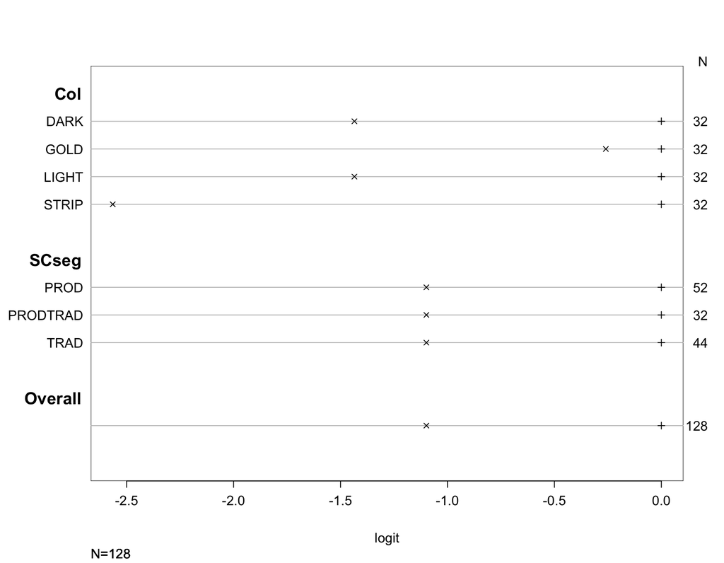

```r
plot(s, which=1:4, pch=1:4, xlab='logit', main=' ', xlim=range(s[,4:5]))
```